[figure not shown]

# If you got here via a link to the slides

Please check out the full git repository for the presentation notebook as well as other example notebooks.

https://github.com/OttoStruve/ipython_notebook_presentation/tree/gsps

# This presentation is actually adapted from one given by [Joshua Barratt](http://serialized.net/2014/09/ipython-notebook-storytelling/) at LinuxCon

```python
from IPython.display import YouTubeVideo
YouTubeVideo('XkXXpaVpNSc', width=853, height=480)
```

[video not shown]

# Outline

- What is the notebook
  - OMG it's the best
  - Quick Demo
  - IPython Ecosystem (2.0 Caveat)
- Why is it awesome
  - Literate Code
  - Sharing
  - Rapid Prototyping/Exploring/Learning
    - `Terminal(Editor <-> Renderer) -> Email` vs Cyclic
  - Blogging
- Workflows (edit, share, publish)
  - Under the hood `ipynb`
  - HTML
  - PDF
  - Gist + nbviewer
- Demos
  - Code Mentorship (sets, objects, katas)
  - Runbooks
  - Log analysis [epic](http://nbviewer.ipython.org/github/koldunovn/nk_public_notebooks/blob/master/Apache_log.ipynb)
  - Shell scripting demo
  - Churn analysis
  - [Latency Heatmap](http://www.brendangregg.com/HeatMaps/latency.html)
- Extending
  - [Extensions](https://github.com/ipython-contrib/IPython-notebook-extensions/wiki)
- It came from inside the presentation!

# What is the notebook?

## A "browser-based interactive computing environment"

[figure not shown]

# Why are we talking about it today?

- Extremely useful tool, like **IT WILL CHANGE YOUR LIFE** useful.
- Makes the (powerful) python data/science/module ecosystem even more powerful
- If you code, (even not in python), sysadmin, write documentation, blog, do any analysis or visualization, you might get a lot out of the notebook.

# Why It's Great

These attributes will come up over and over as we explore this tool.

[figure not shown]

# "Literate Computing"

[figure not shown]

- This is a big part of where the title comes from: it's about the story more than the software.
- IPython's founder, Fernando Perez [@fperez_org](http://twitter.com/fperez_org) has a [blog post](http://blog.fperez.org/2013/04/literate-computing-and-computational.html) on this concept.
- Here's and [example](https://r900-4.as.utexas.edu:9999/notebooks/cosmic_rays/notebooks/The%20High-z%20Cosmic%20Ray%20Background.ipynb)

# Enough Meta: Let's Install It:

## Install Anaconda

- Everything* you need gets installed
- Easy to install additional packages using the `conda` utility
- Even more packages available through [Binstar](https://binstar.org/)

  *Well, almost everything

# If you're morally opposed to [Continuum Analytics](http://continuum.io/)

# you can use `pip install` too.

[figure not shown]

`pip install ipython[all]` Simple as that.*

```
*Dependencies can be painful, YMMV.
```

# Run 'ipython notebook'

[figure not shown]

# Browser Launches

[figure not shown]

# Build a notebook

[figure not shown]

(Actually, it's a process per open notebook.)

# Run A Cell

[figure not shown]

# No Need To Be Local...

[figure not shown]

# Demo Time

[figure not shown]

# Notebook Workflows: The Big Picture

[figure not shown]

Not covered today but cool; clustering capabilities

# How I Fell: Report Workflow v1

[figure not shown]

Problems:

- slow (read whole data file each time, lots of context switching)
- version controlled analysis, but not commentary, difficult to 'go back to'
- Automating requires non-trivial additional dev

# Report Workflow `now()`

Speedups primarily from no context switching, interactivity, and reusable data loading.

[figure not shown]

Reproducible, literate, annotatable, *auditable*.

# An Example of Iterative Workflow

## Viewing and manipulating FITS images in Python

We'll need to import some basic modules to do this; note that `%matplotlib inline` causes images to appear in the notebook.

```python
import numpy as np
import matplotlib as mpl
import matplotlib.pyplot as plt
%matplotlib inline
```

In order to handle FITS images in python, we'll need the `fits` module from `astropy`:

```python
from astropy.io import fits
```

The following is optional, and will only work if you have [Seaborn](http://web.stanford.edu/~mwaskom/software/seaborn/) installed on your machine, but is a significant improvement over the matplotlib defaults.

- Linux: `conda install -c mutirri seaborn`
- OSX: `conda install -c asmeurer seaborn`

```python
import seaborn as sns
sns.set_context('poster')
sns.set_style('white')
```

# Downloading the data

Go to the [SDSS website](http://dr10.sdss3.org/fields/) and download the image of your choice from the SDSS catalog. Here we'll use M42, the Orion Nebula, which looks like this:

[figure not shown]

**You will need to unzip the files!!!** The FITS images you download will be compressed (with a `.gz` or `.bz2` extension). You'll need to extract the file using the program of your choice before proceeding.

## Opening FITS files and loading the image data

Let's open the g-band FITS file and find out what it contains.

```python
hdu_list = fits.open("data/frame-g-006073-4-0063.fits")
hdu_list.info()
```

```
Filename: data/frame-g-006073-4-0063.fits
No.    Name         Type      Cards   Dimensions   Format
0    PRIMARY     PrimaryHDU      96   (2048, 1489)   float32
1                ImageHDU         6   (2048,)      float32
2                BinTableHDU     27   1R x 3C      [49152E, 2048E, 1489E]
3                BinTableHDU     79   1R x 31C     [J, 3A, J, A, D, D, 2J, J, D, D, D, D, D, D, D, D, D, D, D, D, D, D, D, D, D, D, D, D, D, E, E]
```

Generally the image information is located in the `PRIMARY` block. The blocks are numbered and can be accessed by indexing `hdu_list`.

```python
image_data = hdu_list[0].data
```

You data is now stored as a 2-D numpy array. Want to know the dimensions of the image? Just look at the `shape` of the array.

```python
print(type(image_data))
print(image_data.shape)
```

```
<type 'numpy.ndarray'>
(1489, 2048)
```

At this point, we can just close the FITS file. We have stored everything we wanted to a variable.

```python
hdu_list.close()
```

### SHORTCUT

If you don't need to examine the FITS header, you can call `fits.getdata` to bypass the previous steps.

```python
image_data = fits.getdata("data/frame-g-006073-4-0063.fits")
print(type(image_data))
print(image_data.shape)
```

```
<type 'numpy.ndarray'>
(1489, 2048)
```

## Let's get some basic statistics about our image

```python
print('Min:', np.min(image_data))
print('Max:', np.max(image_data))
print('Mean:', np.mean(image_data))
print('Stdev:', np.std(image_data))
```

```
('Min:', 0.037841797)
('Max:', 208.25)
('Mean:', 6.6654449)
('Stdev:', 19.653004)
```

## Viewing the image

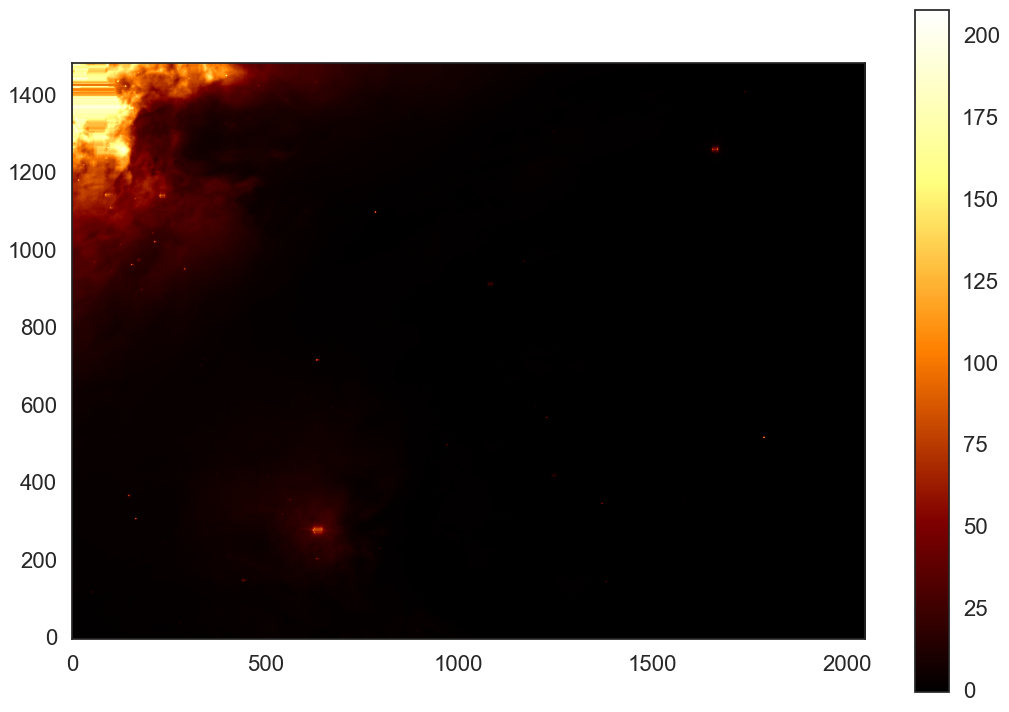

```python
plt.imshow(image_data, cmap='afmhot', origin='lower')
plt.colorbar()
# To see more color maps go to http://wiki.scipy.org/Cookbook/Matplotlib/Show_colormaps
```

Unforturnately, we can't really see much here because of the color range. Lets adjust that manually and see what happens.

## Plotting a histogram

To make a histogram with `matplotlib.pyplot.hist()`, you need to cast the data from a 2-D to array to something one dimensional.

Here we'll use the iterable python object `image_data.flat`.

```python
print(type(image_data.flat))
```

```
<type 'numpy.flatiter'>
```

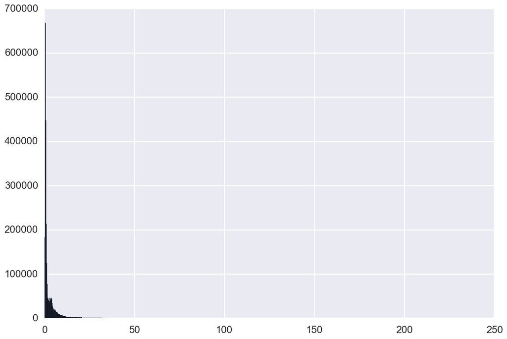

```python
NBINS = 1000
with sns.axes_style("darkgrid"):
    histogram = plt.hist(image_data.flat, NBINS)
```

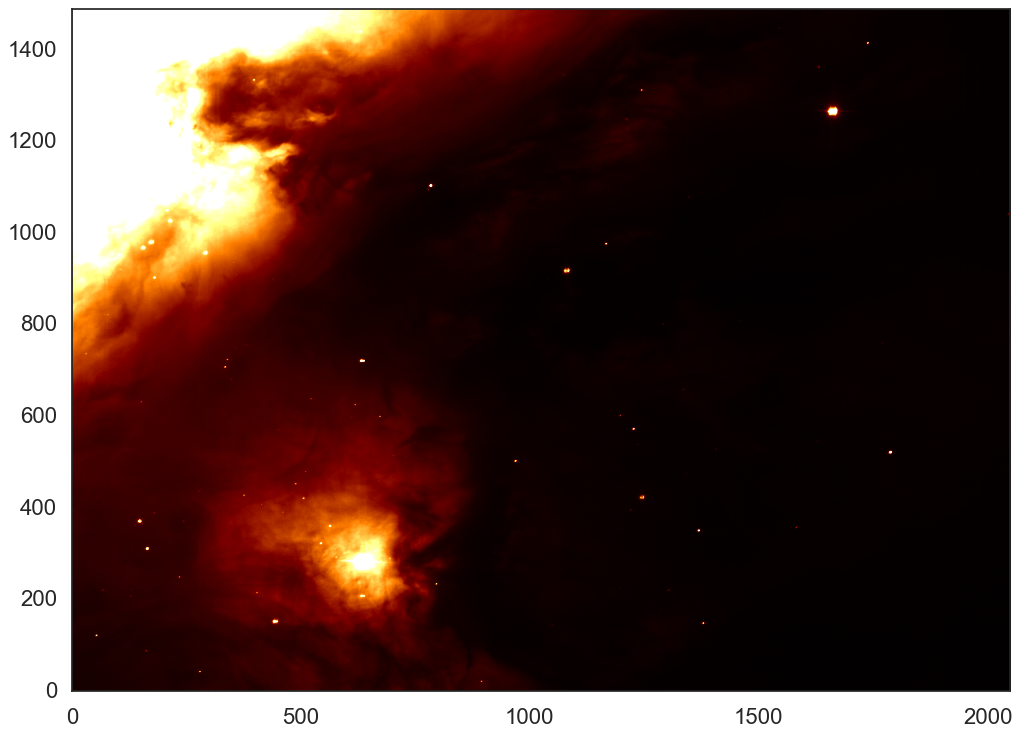

```python
plt.imshow(image_data, cmap='afmhot', origin='lower')
plt.clim(0,30)
```

## Displaying the image with a logarithmic scale

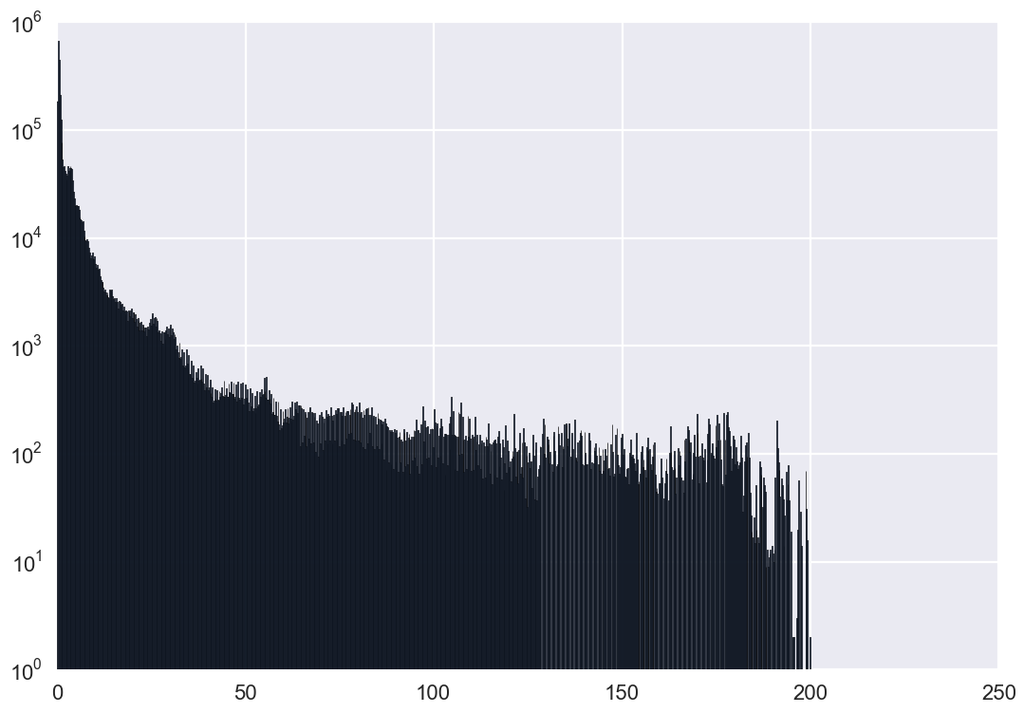

```python
NBINS = 1000
with sns.axes_style("darkgrid"):
    histogram = plt.hist(image_data.flat, NBINS)
    plt.yscale('log', nonposy='clip') #Same histogram, just with logarithmic scaling on the y-axis.
```

To get a logarithmically scaled image, we need to load the `LogNorm` object from `matplotlib`.

```python
from matplotlib.colors import LogNorm
```

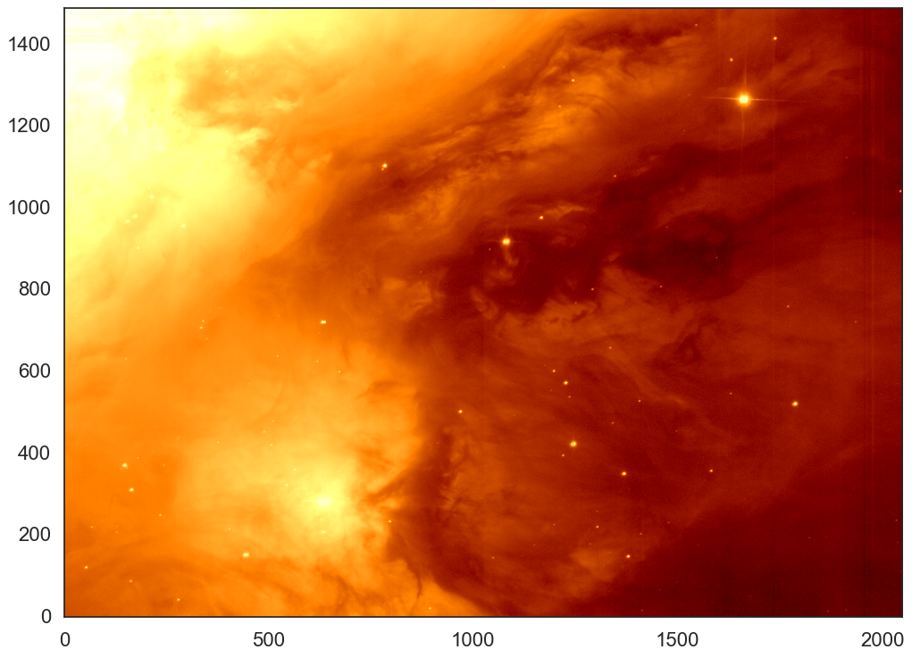

```python
plt.imshow(image_data, cmap='afmhot', norm=LogNorm(), origin='lower')
```

[The notebook](http://localhost:8888/notebooks/astropy-fits.ipynb)

# Why was that cool?

# The "IPython" in "IPython Notebook"`: I*nteractive* Python

[figure not shown]

# The Future

[figure not shown]

# Skills port to the IPython console

```
[jhummel@r900-4 ~]$ ipython
Python 2.7.8 |Anaconda 2.0.1 (64-bit)| (default, Aug 21 2014, 18:22:21)
Type "copyright", "credits" or "license" for more information.

IPython 2.2.0 -- An enhanced Interactive Python.
Anaconda is brought to you by Continuum Analytics.
Please check out: http://continuum.io/thanks and https://binstar.org
?         -> Introduction and overview of IPython's features.
%quickref -> Quick reference.
help      -> Python's own help system.
object?   -> Details about 'object', use 'object??' for extra details.

In [1]: import pyGadget as pyg

In [2]: pyg.
pyg.analyze      pyg.hdf5         pyg.sim          pyg.units
pyg.constants    pyg.multiplot    pyg.sink         pyg.visualize
pyg.coordinates  pyg.nbody        pyg.snapshot
pyg.halo         pyg.plotting     pyg.sph
```

# Interactive Gotcha: Single Namespace

As you recall:

[figure not shown]

# So what happens when you do...

```python
x = 5
x
```

```
5
```

```python
# I ran this cell a few times
x += 1
x
```

```
9
```

# IPython Magic: Development Powertools

Which method is faster?

```python
# make a big array of random numbers
x = np.random.random(500)
```

```python
# Plan A: iterate through and add them up
def addr(numbers):
    tot = 0.
    for entry in numbers:
        tot += entry

# Plan B: use numpy.sum()

# %timeit is IPython Magic to do a quick benchmark
%timeit addr(x)
```

```
10000 loops, best of 3: 100 µs per loop
```

```python
%timeit np.sum(x)
```

```
100000 loops, best of 3: 5.9 µs per loop
```

```python
%lsmagic
```

```
Available line magics:
%alias  %alias_magic  %autocall  %automagic  %autosave  %bookmark  %cat  %cd  %clear  %colors  %config  %connect_info  %cp  %debug  %dhist  %dirs  %doctest_mode  %ed  %edit  %env  %gui  %hist  %history  %install_default_config  %install_ext  %install_profiles  %killbgscripts  %ldir  %less  %lf  %lk …

Available cell magics:
%%!  %%HTML  %%SVG  %%bash  %%capture  %%debug  %%file  %%html  %%javascript  %%latex  %%perl  %%prun  %%pypy  %%python  %%python2  %%python3  %%ruby  %%script  %%sh  %%svg  %%sx  %%system  %%time  %%timeit  %%writefile

Automagic is ON, % prefix IS NOT needed for line magics.
```

### Don't Panic

```
%%writefile?

    %writefile [-a] filename
    Write the contents of the cell to a file.
```

# Exporting

`ipynb format` is clean, readable JSON, which inlines any output results, including base64'd images.

```
...
{
 "cell_type": "markdown",
 "metadata": {
  "slideshow": {
   "slide_type": "slide"
  }
 },
 "source": [
  "# Magic can be magical"
 ]
},
...
```

# Great Notebook Use Cases

There are many use cases where the notebook makes a lot of sense to use. Here are a few illustrated examples:

- [Code Mentorship](http://127.0.0.1:8888/notebooks/FunWithSets.ipynb)
- [Documentation/Runbooks](http://127.0.0.1:8888/notebooks/Command%20Line%20Demo.ipynb)
- [Data Normalization](http://127.0.0.1:8888/notebooks/Ryno%20Reformat.ipynb) (+ Inline Error Resolution)
- [Data Analysis](https://r900-4.as.utexas.edu:9999/notebooks/xrays/notebooks/Pandas%20Column%20Density.ipynb), [Portland Example](http://localhost:8888/notebooks/PortlandCrime.ipynb)
- [Blogging](http://hummel.github.io/blog/2014/10/09/notebook%20example/)
- Wiki'ing...

We won't go into them all for time, but a few highlights:

# Use Case: Data Analysis

This is the gateway drug that gets many people into IPython Notebook. It's the real sweet spot between what makes Python great (pandas, scikit*, numpy, matplotlib, etc) and IPython Notebook great (Literate, Visual, Interactive, Iterative.)

[figure not shown]

Did I permanenently ruin your ability to hear the term 'big data' without thinking of this? You're welcome.

# Use Case: Code Mentorship

[figure not shown]

Because you can't always pair...

# Use Case: Document ALL THE THINGS

[figure not shown]

# Use Case: Wiki Publishing

Also can work for HTML emails, etc.

[figure not shown]

# Use Case: Blogging

It turns out this is super easy!

[figure not shown]

See [nikola](http://www.damian.oquanta.info/posts/ipython-plugin-for-nikola-updated.html) or [pelican](https://github.com/danielfrg/pelican-ipythonnb) for automated ways to blog.

# Rich Objects

You can also define additional `__repr__()`-type methods on custom objects. This has all kinds of fun possibilities.

`_repr_html_()`, `svg`, `png`, `jpeg`, `html`, `javascript`, `latex`.

```python
class FancyText(object):
    def __init__(self, text):
        self.text = text

    def _repr_html_(self):
        """ Use some fancy CSS3 styling when we return this """
        style=("text-shadow: 0 1px 0 #ccc,0 2px 0 #c9c9c9,0 3px 0 #bbb,"
               "0 4px 0 #b9b9b9,0 5px 0 #aaa,0 6px 1px rgba(0,0,0,.1)")

        return '<h1 style="{}">{}</h1>'.format(style, self.text)

FancyText("Hello GSPS!")
```

Hello GSPS!

# IPython (& Notebook) Customization

[figure not shown]

See more on [Profiles](http://ipython.org/ipython-doc/dev/config/intro.html#profiles), [Javascript Extensions](https://github.com/ipython-contrib/IPython-notebook-extensions/wiki), [IPython Extensions](https://github.com/ipython/ipython/wiki/Extensions-Index), and [nbconvert Templates](http://www.damian.oquanta.info/posts/change-the-ipython-slides-defaults-with-an-ipython-config-file.html)

# Javascript, Huh, What is it good for

### Customizing the UI

```
IPython.toolbar.add_buttons_group([
            {
                id : 'toggle_codecells',
                label : 'Toggle codecell display',
                icon : 'icon-list-alt',
                callback : toggle
            }
      ]);
```

### And more...

Turns out, a lot! You can execute anything you can run in an IPython Notebook cell.

```
IPython.notebook.kernel.execute("!rm -rf /")
```

[Demo](http://localhost:8888/notebooks/Javascript%20Demo.ipynb#) Of a less scary example

# Don't forget custom.css

For example, [base16 color schemes](https://github.com/nsonnad/base16-ipython-notebook)

[figure not shown]

# Sharing Notebooks

[figure not shown]

- [Color schemes](http://www.damian.oquanta.info/posts/48-themes-for-your-ipython-notebook.html)
- [Interactive Demos with IPython](http://ipython.org/ipython-doc/dev/interactive/reference.html#interactive-demos-with-ipython)
- [Customizing reveal.js](http://www.damian.oquanta.info//posts/change-the-ipython-slides-defaults-with-an-ipython-config-file.html)
- [Quickly Sharing Notebooks as Gists](http://nbviewer.ipython.org/gist/minrk/4982809)
- [Great intro to the basics](http://nbviewer.ipython.org/url/www.southampton.ac.uk/~fangohr/training/python/snippets/day4/IPython-beyond-plain-Python-Fernando-Perez.ipynb?create=1)
- [IPython In Depth](https://github.com/ipython/ipython-in-depth/tree/master/notebooks) notebook collection
- [Pygments Magic](https://gist.github.com/jiffyclub/5385501)

# IT CAME FROM INSIDE THE NOTEBOOK

[figure not shown]

- Highly technical decks can be created quickly
- Collaboration features are still quite useful
- [Check It Out](http://localhost:8888/notebooks/Presentation.ipynb)

# Building slides

- Turn on the 'slideshow' cell toolbar
- Types:
  - Slide: start a new slide
  - `-`: Continue a slide
  - Sub-Slide: Make a 'down' slide
  - Fragment: Make a 'bullet' type incoming slide
  - Skip: keep in the notebook, not the deck
  - Notes: speaker notes

```python
!ipython nbconvert Presentation.ipynb --to slides
```

```
[NbConvertApp] Using existing profile dir: u'/Users/jhummel/.ipython/profile_default'
[NbConvertApp] Converting notebook Presentation.ipynb to slides
[NbConvertApp] Support files will be in Presentation_files/
[NbConvertApp] Loaded template slides_reveal.tpl
[NbConvertApp] Writing 1882989 bytes to Presentation.slides.html
```

# Other Resources

## Try It Online

- [Wakari](https://wakari.io/)

## Installing

- [Anaconda](http://continuum.io/downloads) **OR**
- `$ pip install ipython[all]` (`brew install python`) **OR**
- docker-ipython
  - Preloaded with lots of sometimes challenging-to-install packages like Pattern, NLTK, Pandas, NumPy, SciPy, Numba, Biopython...

## Learning More

- Slides will be up on the GSPS site later.
- Complete source for this presentation is available on [github](https://github.com/OttoStruve/ipython_notebook_presentation)!
- [A Gallery of Interesting IPython Notebooks](https://github.com/ipython/ipython/wiki/A-gallery-of-interesting-IPython-Notebooks)
- [Extensions](https://github.com/ipython-contrib/IPython-notebook-extensions/wiki)
- nbviewer (good way to discover organically)
- Pandas/numpy, Statsmodels, Matplotlib, bokeh, vincent, scikit-learn, scikit-image, .... (F150!)
- Talk to me!

### Credits

- Quill designed by [Simple Icons](http://www.thenounproject.com/SimpleIcons) from the [Noun Project](http://www.thenounproject.com),
- Settings designed by [Clément thorez](http://www.thenounproject.com/clementthorez) from the [Noun Project](http://www.thenounproject.com),
- Photo designed by [Simple Icons](http://www.thenounproject.com/SimpleIcons) from the [Noun Project](http://www.thenounproject.com),
- Recurring Edit designed by [Lemon Liu](http://www.thenounproject.com/lemonliu) from the [Noun Project](http://www.thenounproject.com)
- Cover page texture from grungetextures via Flickr.